# My Journey with TimeVista: Unlocking the Secrets of Time Series Analysis

As someone who has always been fascinated by the patterns and rhythms of data, I recently embarked on a journey to deepen my understanding of time series analysis. I had experimented with various tools and techniques before, but none seemed to offer the comprehensive and intuitive experience I was looking for—until I discovered TimeVista.

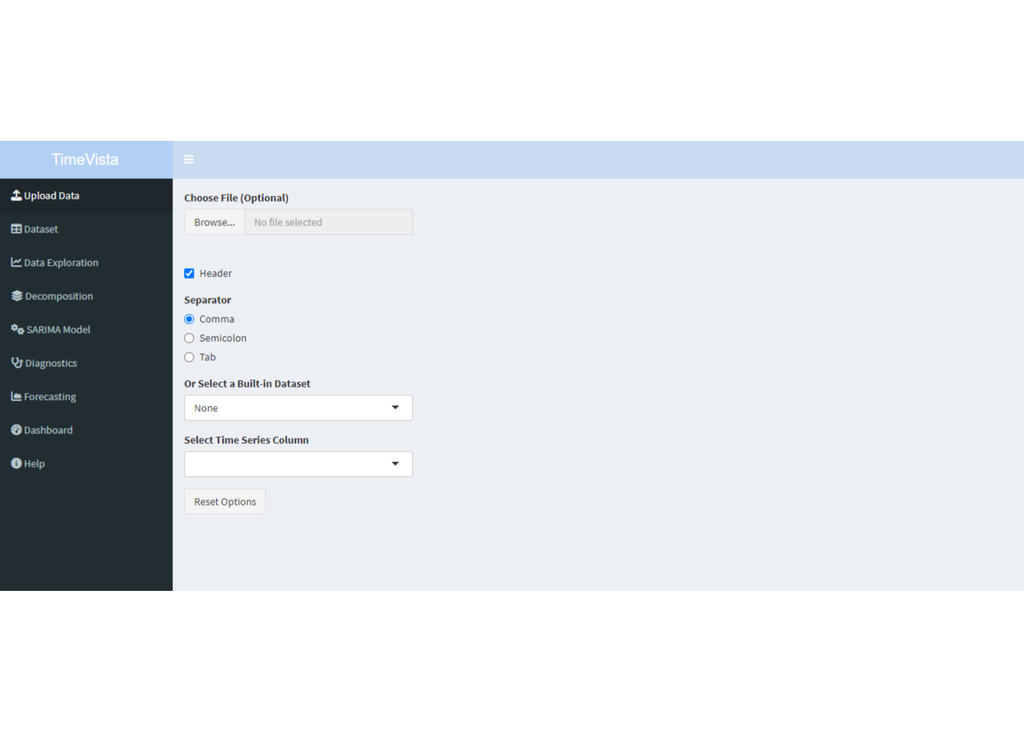

## Discovering TimeVista

My adventure began with a simple curiosity: how could I better predict and understand trends in data that unfold over time? After a bit of research, I stumbled upon TimeVista, a Shiny app designed specifically for time series analysis. Intrigued by its promise of an all-in-one solution for exploring, decomposing, modeling, diagnosing, and forecasting time series data, I decided to give it a try.

## Step 1: Uploading and Selecting Data

The first thing that struck me about TimeVista was its user-friendly interface. I easily navigated to the “Upload Data” tab, where I had the option to upload my own CSV file or select from a range of built-in datasets. For my initial exploration, I chose the “AirPassengers” dataset, which contains monthly totals of international airline passengers from 1949 to 1960.

## Step 2: Exploring the Data

With the dataset loaded, I moved to the “Dataset” tab to take a closer look. TimeVista displayed the data in a neat, interactive table, allowing me to download it if needed. The real magic happened in the “Data Exploration” tab, where a time series plot and summary statistics awaited me. I was immediately impressed by the clarity of the visualizations and the insightful summary that provided a solid understanding of the data’s characteristics.

```r
output$tsPlot <- renderPlot({
  req(tsData())
  autoplot(tsData()) + ggtitle("Time Series Plot") +
    theme_minimal() +
    theme(text = element_text(size = 12), axis.text.x = element_text(angle = 45, hjust = 1))
})
```

## Step 3: Decomposing the Time Series

Next, I ventured into the “Decomposition” tab. Here, TimeVista allowed me to break down the time series into its trend, seasonal, and residual components. Seeing these components laid out clearly helped me understand the underlying patterns driving the data. The decomposition plot was particularly illuminating, revealing the seasonal peaks and long-term trends in airline passenger numbers.

```r
output$decompPlot <- renderPlot({
  req(tsData())
  ts_decomp <- decompose(tsData())
  autoplot(ts_decomp) + ggtitle("Decomposition Plot") +
    theme_minimal() +
    theme(text = element_text(size = 12))
})
```

## Step 4: Building the SARIMA Model

Eager to predict future trends, I moved to the “SARIMA Model” tab. TimeVista’s use of the auto.arima function simplified the process of fitting a SARIMA model to my data. The app presented a detailed summary of the model parameters, giving me confidence in the robustness of the forecasts it would generate.

```r
output$sarimaModel <- renderPrint({
  req(tsData())
  fit <- auto.arima(tsData())
  summary(fit)
})
```

## Step 5: Diagnostics and Forecasting

Ensuring the reliability of my model was crucial, so I explored the “Diagnostics” tab. TimeVista provided diagnostic plots that helped me verify the model’s accuracy and identify any potential issues. With diagnostics in hand, I proceeded to the “Forecasting” tab, where I specified a 12-month forecast horizon. The resulting forecast plot was both intuitive and informative, giving me a clear view of the expected future trends.

```r
output$forecastPlot <- renderPlot({
  req(tsData(), input$h)
  fit <- auto.arima(tsData())
  forecasted <- forecast(fit, h = input$h)
  autoplot(forecasted) + ggtitle("Forecast Plot") +
    theme_minimal() +
    theme(text = element_text(size = 12))
})
```

## Step 6: Viewing the Dashboard

The final stop on my journey was the “Dashboard” tab, which brought together all the key elements of my analysis. Here, I could see the decomposition plot, SARIMA model summary, and forecast plot all in one place. This comprehensive view made it easy to review my work and present my findings to others.

```r
output$dashboardForecastPlot <- renderPlot({
  req(tsData(), input$h)
  fit <- auto.arima(tsData())
  forecasted <- forecast(fit, h = input$h)
  autoplot(forecasted) + ggtitle("Forecast Plot") + theme_minimal()
})
```

## Empowered by TimeVista

Reflecting on my experience with TimeVista, I realize just how much this tool has transformed my approach to time series analysis. What once seemed like a complex and daunting task is now an engaging and insightful process. TimeVista has not only equipped me with the tools I need to analyze and forecast time series data but has also deepened my appreciation for the stories data can tell.

Whether you’re a data scientist, business analyst, or simply someone passionate about data, I encourage you to explore TimeVista. It’s more than just an app—it’s a gateway to unlocking the secrets of your time series data. Dive in and discover the power of TimeVista for yourself!